# Functional analysis of regulated psites upon TCR stimulation

Marie Locard-Paulet

Wed Sep 19 09:16:07 2018

# Generation of the input data

## phosphorylation sites IDs

There are some issues with protein IDs. For peptide identification. Some peptides are ambiguous, they can belong to several proteins/proteoforms with common sequences. I keep the `Proteins` field in the raw table. This allows us to keep the information of what phosphosite could belong to several proteoforms and what the corresponding phosphorylation position in the protein sequence are. I have ordered them by alphabetical order.

To generate the phosphosite IDs, I keep all possible protein identifications (Uniprot entry names) separated by “;”, together with their respective positions separated by “;”.

## Filters and statistical analysis

See the data preparation in the document `DataPreparation.html`.

I log2-transform the data set. For each replicate independently, I calculate the mean of the injection replicates in each time point.

From there, I run a loop of 200 iterations that contain the following steps:

For each phosphorylation site, when it is not measured in any biological replicate for a condition (or only one biological replicate), I replace missing values with a random value generated around the 5% quantile of the intensities for each condition, using the standard deviation of the dataset (technical variance) per condition.

For each phosphorylation site, I normalise the biological replicates using the mean of the signal across all the conditions (after replacement of missing values).

I only keep the phosphorylation sites that have a minimum of 3 time points with values in the same 2 replicates.

I perform an anova on each phosphorylation site across the 6 time points. Then, I correct the pvalue with Tukey HSD.

I calculate the fold changes per time point relative to each other.

The thresholds for a phosphorylation site to be regulated is having a pvalue of the Anova under or equal to 0.05, and the best pvalue from Tukey under or equal to 0.05 with a corresponding absolute log2-transformed fold change above or equal to log2(1.75). I only keep the pvalue and FC for the comparisons where there are a minimum of 2 points per condition.

This is performed 200 times, then I keep as variants only the sites that pass these threshold a minimum of 90% of the times. All the fold change values reported are the averages of the 200 iterations.

I flagged the sites that were also regulated in the protein data set (based on FC only).

# ProteomeScout analysis

I work with [ProteomeScout](https://proteomescout.wustl.edu).

After retrieving information from the ProteomeScout website (07/09/2018). The phosphorylation database is dated of Mon Sep 3 15:25:55 2018.

*I previously removed from the document the characters “’”.*

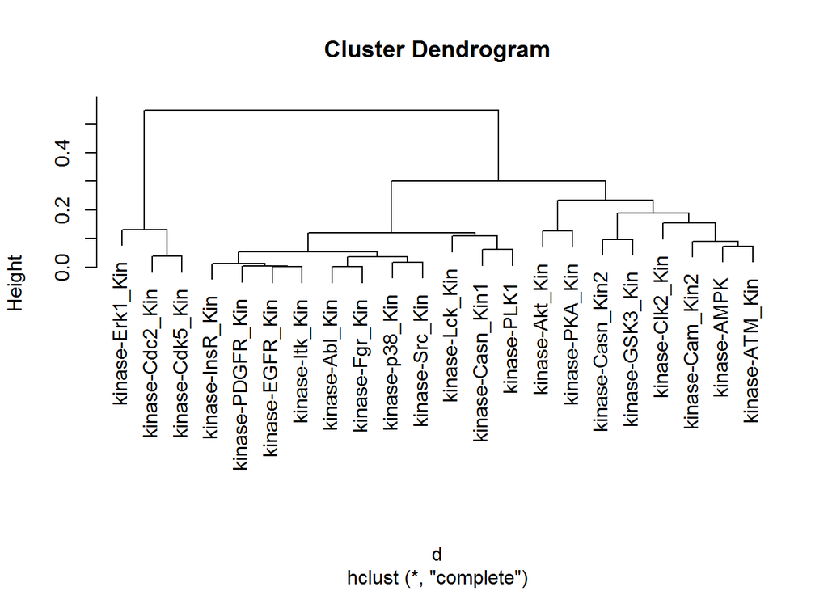

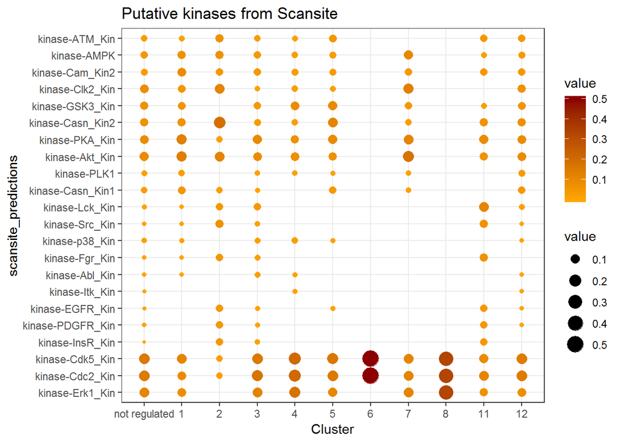

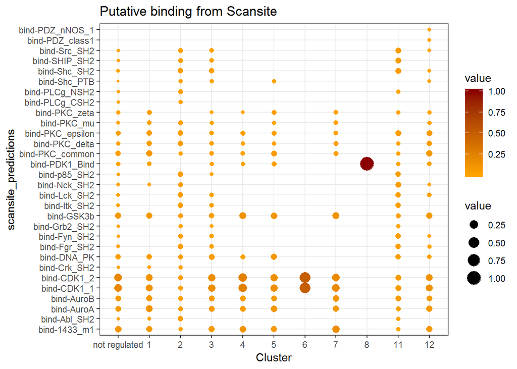

[figure not shown]

[figure not shown]